# Vehicles in the park

# Scores

Before plotting the scales, we make some small tweaks to the `scores` dataset: 1. to change the text for each item to be the full description shown to participants, 2. to add a column with data from Tobia’s study.

```r
scores_raw <- scores

# fix the names of the items - instead of the shorthand names, use the full item_description as shown to participants
scores <- scores_raw %>%
  mutate(item_name_old = item_name) %>%
  select(-item_name) %>%
  left_join(items %>% select(individual = item_num, item_name = item_description), by = "individual") %>%
  relocate(item_name, .after = individual) %>%
  # deal with one extra-long item by manually setting its text (including an asterisk so this can be explained in the figure caption)
  mutate(item_name = if_else(individual == 24, "WWII truck*", item_name))

# add the Tobia percentages for comparison
tobia_percentages <- read_csv(here::here("data-raw/tobia-percentages.csv")) %>%
  # adjust item names to match
  select(item_num, tobia_percentage) %>%
  left_join(scores %>% select(item_num = individual, item_name), by = "item_num")

scores <- scores %>%
  left_join(tobia_percentages %>% select(individual = item_num, tobia_percentage), by = "individual")

scores
```

| individual | item_name | nuisance_est | vehicle_est | violation_est | nuisance_se | vehicle_se | violation_se | item_name_old | tobia_percentage |
| --- | --- | --- | --- | --- | --- | --- | --- | --- | --- |
| 22 | Truck | 2.3753875 | 3.56818705 | 3.70464674 | 0.2492220 | 0.3187811 | 0.3770248 | Truck | 97.255478 |
| 14 | Helicopter | 2.1365008 | 1.18115975 | 1.86446251 | 0.2348185 | 0.2630020 | 0.2765370 | Helicopter | 78.403131 |
| 7 | Bus | 2.0939810 | 3.63409124 | 3.03961076 | 0.2407744 | 0.3116179 | 0.3162993 | Bus | 94.457441 |
| 1 | Airplane | 1.9507478 | 1.99187342 | 2.00028212 | 0.2390358 | 0.2720872 | 0.2875034 | Airplane | 74.229011 |
| 3 | Automobile | 1.4725333 | 3.68194555 | 2.62725636 | 0.2132543 | 0.3049798 | 0.2897540 | Automobile | 93.173096 |
| 15 | Vehicle | 1.4630198 | 3.91317117 | 3.06200533 | 0.2176885 | 0.3341861 | 0.3164476 | Vehicle | 93.173096 |
| 17 | Moped | 1.4801032 | 1.54246232 | 1.43140579 | 0.2161980 | 0.2749831 | 0.2612191 | Moped | 82.256166 |
| 9 | Car | 1.2353504 | 5.15104652 | 2.82869290 | 0.2119117 | 0.4349583 | 0.2951870 | Car | 94.457441 |
| 12 | Drone | 0.9786769 | -2.82034886 | -0.85207535 | 0.2053920 | 0.2632260 | 0.2334831 | Drone | 20.286531 |
| 10 | Horse-drawn carriage | 0.5111787 | 0.30088600 | 0.80757574 | 0.2012828 | 0.2489738 | 0.2556846 | Carriage | 74.229011 |

[output cut: 15 more lines]

We also produce a “long” version of the scores, with separate rows for each study, as this is needed for plotting.

```r
scores_long <- scores %>%
  # keep the vehicle score for later
  mutate(vehicleness = vehicle_est) %>%
  # put all three scales (nuisance, vehicle, violation) into long format
  pivot_longer(
    cols = c(ends_with("_est"), ends_with("_se")),
    names_sep = "_",
    names_to = c("scale", "param")
  ) %>%
  pivot_wider(
    names_from = "param",
    values_from = "value"
  )
```

This shows the scores for each item on each scale, ordered by the scores for `vehicle`:

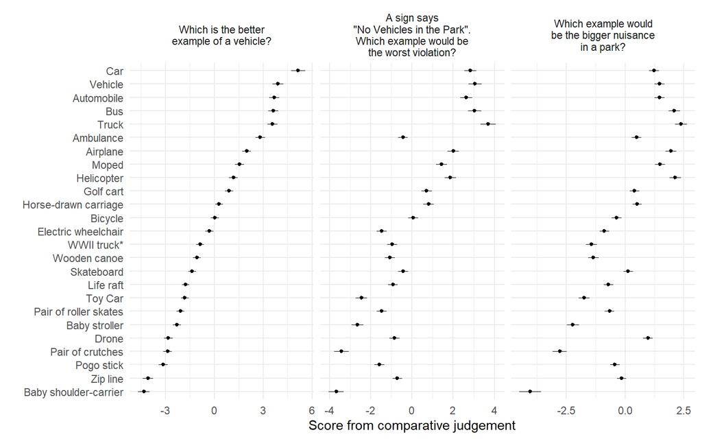

```r
theme_set(theme_minimal())

scale_plot <- scores_long %>%
  # order items by the vehicleness score
  mutate(item_name = fct_reorder(item_name, vehicleness)) %>%
  # fix the order of the panels
  mutate(scale = fct_relevel(scale, "vehicle", "violation", "nuisance")) %>%
  ggplot(aes(x = est, y = item_name)) +
  geom_pointrange(aes(xmin = est - se, xmax = est + se), size = 0.1) +
  facet_grid(cols = vars(scale), scales = "free", labeller = labeller(
    scale = judging_prompts
  )) +
  theme_minimal() +
  labs(x = "Score from comparative judgement", y = "")
  #labs(caption = "* shown to participants as: A nonfunctioning commemorative truck (e.g. a World War II Truck that has been decorated as a World War II monument)")

scale_plot
```

```r
ggsave(here::here("figs/scale-plot.pdf"), units = "cm", width = 18, height = 14)
```

- shown to participants as: A nonfunctioning commemorative truck (e.g. a World War II Truck that has been decorated as a World War II monument)

This shows:

1. the `violation` and `nusiance` scales have a different pattern from `vehicle`, and
2. while different from `vehicle`, the `violation` and `nusiance` scales look quite similar to each other.
3. Some of the items have noticeably different scores between the scales, e.g. ambulance near the top.

```r
scores_long %>%
  filter(item_name == "Ambulance") %>%
  select(item_name, scale, est, se)
```

| item_name | scale | est | se |
| --- | --- | --- | --- |
| Ambulance | nuisance | 0.4862219 | 0.2016600 |
| Ambulance | vehicle | 2.8248904 | 0.2978687 |
| Ambulance | violation | -0.4371060 | 0.2301998 |

```r
scores_long %>%
  filter(item_name == "Zip line") %>%
  select(item_name, scale, est, se)
```

| item_name | scale | est | se |
| --- | --- | --- | --- |
| Zip line | nuisance | -0.1465632 | 0.2026541 |
| Zip line | vehicle | -4.0625508 | 0.3254469 |
| Zip line | violation | -0.7111995 | 0.2347730 |

## Comparison with Tobia

Alternatively, this can be done ordering the words by the percentage from Tobia, to highlight differences in our `vehicle` scale:

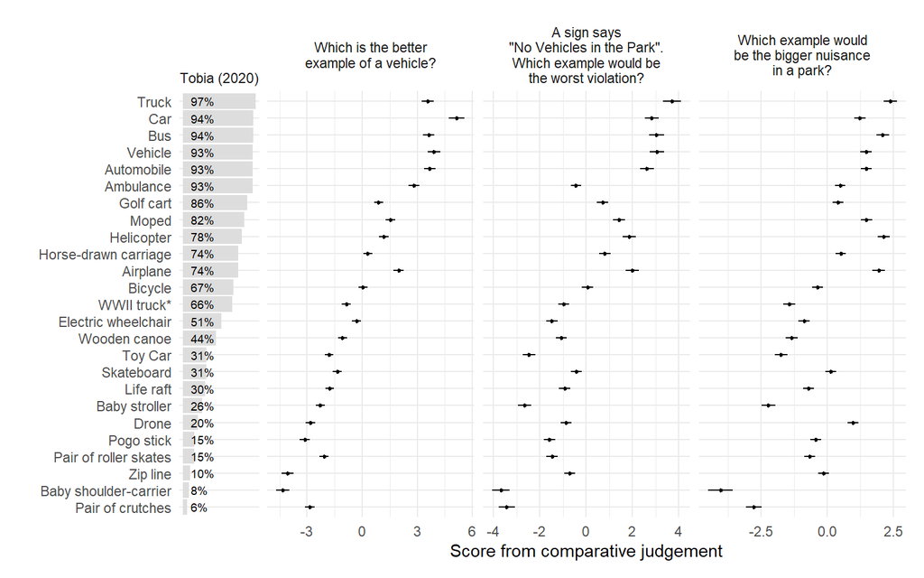

```r
library(patchwork)

# Assemble the left-hand panel, showing percentages from Tobia
plt_tobia <- tobia_percentages %>%
  mutate(item_name = fct_reorder(item_name, tobia_percentage),
         title = "Tobia (2020)") %>%
  ggplot(aes(x = 0.1, y = item_name, label = paste0(round(tobia_percentage, 0), "%"))) +
  geom_bar(aes(x = tobia_percentage/100), stat = "identity", fill = "#dddddd") +
  geom_text(hjust = 0, size = 2.5) +
  facet_grid(cols = vars(title)) +
  theme_minimal() +
  theme(axis.title.x=element_blank(),
        axis.text.x=element_blank(),
        axis.ticks.x=element_blank(),
        panel.grid.major.x = element_blank(),
        panel.grid.minor.x = element_blank()) +
  labs(y = "")

# Redo the scale plot, with the ordering based on Tobia's scores now
scale_plot_by_tobia <- scores_long %>%
  # order items by Tobia percentage
  mutate(item_name = fct_reorder(item_name, tobia_percentage)) %>%
  # fix the order of the panels
  mutate(scale = fct_relevel(scale, "vehicle", "violation", "nuisance")) %>%
  ggplot(aes(x = est, y = item_name)) +
  geom_pointrange(aes(xmin = est - se, xmax = est + se), size = 0.4, fatten = 0.7) +
  facet_grid(cols = vars(scale), scales = "free", labeller = labeller(
    scale = judging_prompts
  )) +
  theme_minimal() +
  labs(x = "Score from comparative judgement", y = "")

# Combine the two plots together
patchwork::wrap_plots(
  plt_tobia,
  plot_spacer(), # given width = -0.4 below to reduce space between the two panels
  scale_plot_by_tobia +
    theme(
      axis.title.y = element_blank(),
      axis.text.y = element_blank(),
      axis.ticks.y = element_blank()
    )
) +
  plot_layout(widths = c(1, -0.4, 8))
```

```r
ggsave(here::here("figs/scale-plot-tobia-order.pdf"), units = "cm", width = 20, height = 12)
```

# Correlations

## Plotting an example

Plotting scores for `vehicle` against `violation` shows they are well-correlated, and shows some outliers:

- Ambulance is high on the `vehicle` scale but lower on the `violation` scale than would be predicted by the correlation (i.e. although it is regarded as a vehicle, it would not be felt as a violation of the rule)
- Zip-line is low on the `vehicle` scale, but higher on the `violation` scale than would be predicted by the correlation (i.e. while it is not regarded as a vehicle, it would be felt as a violation)

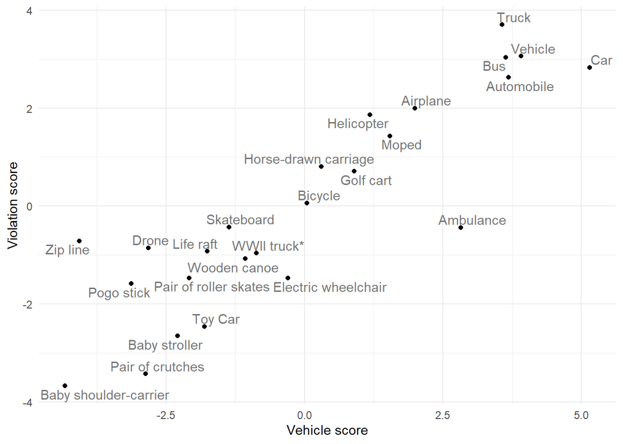

```r
scores %>%
  ggplot(aes(x = vehicle_est, y = violation_est, label = item_name)) +
  geom_point() +
  ggrepel::geom_text_repel( box.padding = 0.1, min.segment.length = 0.2, colour = "#777777") +
  labs(x = "Vehicle score", y = "Violation score")
```